# Background

A significant number of hotel bookings are called off due to cancellations or no-shows. The typical reasons for cancellations include change of plans, scheduling conflicts, etc. This is often made easier by the option to do so free of charge or preferably at a low cost which is beneficial to hotel guests but it is a less desirable and possibly revenue-diminishing factor for hotels to deal with. Such losses are particularly high on last-minute cancellations.

The new technologies involving online booking channels have dramatically changed customers’ booking possibilities and behavior. This adds a further dimension to the challenge of how hotels handle cancellations, which are no longer limited to traditional booking and guest characteristics.

The cancellation of bookings impact a hotel on various fronts:

1. Loss of resources (revenue) when the hotel cannot resell the room.
2. Additional costs of distribution channels by increasing commissions or paying for publicity to help sell these rooms.
3. Lowering prices last minute, so the hotel can resell a room, resulting in reducing the profit margin.
4. Human resources to make arrangements for the guests.

# Objective

The increasing number of cancellations calls for a Machine Learning based solution that can help in predicting which booking is likely to be canceled. Star Hotels Group has a chain of hotels in Portugal, they are facing problems with the high number of booking cancellations and have reached out to your firm for data-driven solutions. You as a data scientist have to analyze the data provided to find which factors have a high influence on booking cancellations, build a predictive model that can predict which booking is going to be canceled in advance, and help in formulating profitable policies for cancellations and refunds.

# Key Questions

1. What are the busiest months in the hotel?
2. Which market segment do most of the guests come from?
3. Hotel rates are dynamic and change according to demand and customer demographics. What are the differences in room prices in different market segments?
4. What percentage of bookings are canceled?
5. Repeating guests are the guests who stay in the hotel often and are important to brand equity. What percentage of repeating guests cancel?
6. Many guests have special requirements when booking a hotel room. Do these requirements affect booking cancellation?

# Data Description

1. no_of_adults: Number of adults
2. no_of_children: Number of Children
3. no_of_weekend_nights: Number of weekend nights (Saturday or Sunday) the guest stayed or booked to stay at the hotel
4. no_of_week_nights: Number of week nights (Monday to Friday) the guest stayed or booked to stay at the hotel
5. type_of_meal_plan: Type of meal plan booked by the customer:  
   a. Not Selected – No meal plan selected  
   b. Meal Plan 1 – Breakfast  
   c. Meal Plan 2 – Half board (breakfast and one other meal)  
   d. Meal Plan 3 – Full board (breakfast, lunch, and dinner)
6. required_car_parking_space: Does the customer require a car parking space? (0 - No, 1- Yes)
7. room_type_reserved: Type of room reserved by the customer. The values are ciphered (encoded) by Star Hotels Group
8. lead_time: Number of days between the date of booking and the arrival date
9. arrival_year: Year of arrival date
10. arrival_month: Month of arrival date
11. arrival_date: Date of the month
12. market_segment_type: Market segment designation.
13. repeated_guest: Is the customer a repeated guest? (0 - No, 1- Yes)
14. no_of_previous_cancellations: Number of previous bookings that were canceled by the customer prior to the current booking
15. no_of_previous_bookings_not_canceled: Number of previous bookings not canceled by the customer prior to the current booking
16. avg_price_per_room: Average price per day of the reservation; prices of the rooms are dynamic. (in euros)
17. no_of_special_requests: Total number of special requests made by the customer (e.g. high floor, view from the room, etc)
18. booking_status: Flag indicating if the booking was canceled or not.

```python
# import the important packages
import pandas as pd
# library used for data manipulation and analysis

import numpy as np  # library used for working with arrays

import matplotlib.pyplot as plt  # library for visualization

import seaborn as sns  # library for visualization

%matplotlib inline

import scipy.stats as stats  # this library contains a large number of probability distributions as well as a growing library of statistical functions
from scipy.stats import uniform
from scipy.stats import norm
from scipy.stats import expon
from scipy.stats import binom
from scipy.stats import ttest_1samp
from scipy.stats import ttest_ind
from scipy.stats import ttest_rel
from statsmodels.stats.proportion import proportions_ztest
from scipy.stats import chi2
from scipy.stats import f
from scipy.stats import chi2_contingency
from scipy.stats import levene
from scipy.stats import f_oneway
from statsmodels.stats.multicomp import pairwise_tukeyhsd
import pylab
import scipy.stats as stats
import statsmodels.stats.api as sms
from statsmodels.compat import lzip

#regression
from sklearn.linear_model import LinearRegression
from sklearn.model_selection import train_test_split #sklearn package's randomized data splitting function
from sklearn.preprocessing import PolynomialFeatures
from sklearn import linear_model
from sklearn.metrics import mean_squared_error
import statsmodels.api as sm
from sklearn.metrics import mean_absolute_error, mean_squared_error, r2_score
from sklearn.tree import DecisionTreeClassifier
from sklearn import tree
from sklearn.linear_model import LogisticRegression
from sklearn import metrics
from sklearn.tree import DecisionTreeClassifier
from sklearn import tree
from sklearn.model_selection import GridSearchCV

pd.set_option('display.max_columns',None)
pd.set_option('display.max_rows',200)
```

```python
book = pd.read_csv('StarHotelsGroup.csv')
book.head(10)
```

|  | no_of_adults | no_of_children | no_of_weekend_nights | no_of_week_nights | type_of_meal_plan | required_car_parking_space | room_type_reserved | lead_time | arrival_year | arrival_month | arrival_date | market_segment_type | repeated_guest | no_of_previous_cancellations | no_of_previous_bookings_not_canceled | avg_price_per_room | no_of_special_requests | booking_status |
| --- | --- | --- | --- | --- | --- | --- | --- | --- | --- | --- | --- | --- | --- | --- | --- | --- | --- | --- |
| 0 | 2 | 0 | 1 | 2 | Meal Plan 1 | 0 | Room_Type 1 | 224 | 2017 | 10 | 2 | Offline | 0 | 0 | 0 | 65.00 | 0 | Not_Canceled |
| 1 | 2 | 0 | 2 | 3 | Not Selected | 0 | Room_Type 1 | 5 | 2018 | 11 | 6 | Online | 0 | 0 | 0 | 106.68 | 1 | Not_Canceled |
| 2 | 1 | 0 | 2 | 1 | Meal Plan 1 | 0 | Room_Type 1 | 1 | 2018 | 2 | 28 | Online | 0 | 0 | 0 | 60.00 | 0 | Canceled |
| 3 | 2 | 0 | 0 | 2 | Meal Plan 1 | 0 | Room_Type 1 | 211 | 2018 | 5 | 20 | Online | 0 | 0 | 0 | 100.00 | 0 | Canceled |
| 4 | 3 | 0 | 0 | 3 | Not Selected | 0 | Room_Type 1 | 277 | 2019 | 7 | 13 | Online | 0 | 0 | 0 | 89.10 | 2 | Canceled |
| 5 | 2 | 0 | 1 | 1 | Not Selected | 0 | Room_Type 1 | 48 | 2018 | 4 | 11 | Online | 0 | 0 | 0 | 94.50 | 0 | Canceled |
| 6 | 1 | 0 | 0 | 3 | Meal Plan 1 | 0 | Room_Type 1 | 38 | 2019 | 6 | 20 | Online | 0 | 0 | 0 | 160.00 | 1 | Not_Canceled |
| 7 | 2 | 0 | 0 | 2 | Meal Plan 2 | 0 | Room_Type 1 | 346 | 2018 | 9 | 13 | Online | 0 | 0 | 0 | 115.00 | 1 | Canceled |
| 8 | 2 | 0 | 1 | 3 | Meal Plan 1 | 0 | Room_Type 1 | 34 | 2017 | 10 | 15 | Online | 0 | 0 | 0 | 107.55 | 1 | Not_Canceled |
| 9 | 2 | 0 | 0 | 4 | Meal Plan 1 | 0 | Room_Type 1 | 133 | 2019 | 4 | 19 | Offline | 0 | 0 | 0 | 124.00 | 0 | Not_Canceled |

```python
book.shape
```

```
(56926, 18)
```

```python
book.info()
```

```
<class 'pandas.core.frame.DataFrame'>
RangeIndex: 56926 entries, 0 to 56925
Data columns (total 18 columns):
 #   Column                                Non-Null Count  Dtype
---  ------                                --------------  -----
 0   no_of_adults                          56926 non-null  int64
 1   no_of_children                        56926 non-null  int64
 2   no_of_weekend_nights                  56926 non-null  int64
 3   no_of_week_nights                     56926 non-null  int64
 4   type_of_meal_plan                     56926 non-null  object
 5   required_car_parking_space            56926 non-null  int64
 6   room_type_reserved                    56926 non-null  object
 7   lead_time                             56926 non-null  int64
 8   arrival_year                          56926 non-null  int64
 9   arrival_month                         56926 non-null  int64
 10  arrival_date                          56926 non-null  int64
 11  market_segment_type                   56926 non-null  object
 12  repeated_guest                        56926 non-null  int64
 13  no_of_previous_cancellations          56926 non-null  int64
 14  no_of_previous_bookings_not_canceled  56926 non-null  int64
 15  avg_price_per_room                    56926 non-null  float64
 16  no_of_special_requests                56926 non-null  int64
 17  booking_status                        56926 non-null  object
dtypes: float64(1), int64(13), object(4)
memory usage: 7.8+ MB
```

**Observations**

- There are 56,926 rows and 18 columns.
- Column names are all written properly and can be used easily.
- Some variables will have to be converted.
- Dependent variable is *booking_status*.

```python
# let's create a copy of the data to avoid any changes to original data
bc = book.copy()
```

## Data Preprocessing

### Missing Value Treatment

```python
# checking for missing values
bc.isnull().sum()
```

```
no_of_adults                            0
no_of_children                          0
no_of_weekend_nights                    0
no_of_week_nights                       0
type_of_meal_plan                       0
required_car_parking_space              0
room_type_reserved                      0
lead_time                               0
arrival_year                            0
arrival_month                           0
arrival_date                            0
market_segment_type                     0
repeated_guest                          0
no_of_previous_cancellations            0
no_of_previous_bookings_not_canceled    0
avg_price_per_room                      0
no_of_special_requests                  0
booking_status                          0
dtype: int64
```

There are no missing values

```python
bc.describe(include='all').T
```

|  | count | unique | top | freq | mean | std | min | 25% | 50% | 75% | max |
| --- | --- | --- | --- | --- | --- | --- | --- | --- | --- | --- | --- |
| no_of_adults | 56926.0 | NaN | NaN | NaN | 1.875856 | 0.518667 | 0.0 | 2.0 | 2.0 | 2.0 | 4.0 |
| no_of_children | 56926.0 | NaN | NaN | NaN | 0.110723 | 0.408885 | 0.0 | 0.0 | 0.0 | 0.0 | 10.0 |
| no_of_weekend_nights | 56926.0 | NaN | NaN | NaN | 0.83584 | 0.8759 | 0.0 | 0.0 | 1.0 | 2.0 | 8.0 |
| no_of_week_nights | 56926.0 | NaN | NaN | NaN | 2.261901 | 1.432371 | 0.0 | 1.0 | 2.0 | 3.0 | 17.0 |
| type_of_meal_plan | 56926 | 4 | Meal Plan 1 | 42330 | NaN | NaN | NaN | NaN | NaN | NaN | NaN |
| required_car_parking_space | 56926.0 | NaN | NaN | NaN | 0.026332 | 0.160123 | 0.0 | 0.0 | 0.0 | 0.0 | 1.0 |
| room_type_reserved | 56926 | 7 | Room_Type 1 | 42807 | NaN | NaN | NaN | NaN | NaN | NaN | NaN |
| lead_time | 56926.0 | NaN | NaN | NaN | 93.713909 | 92.408296 | 0.0 | 21.0 | 65.0 | 142.0 | 521.0 |
| arrival_year | 56926.0 | NaN | NaN | NaN | 2018.24834 | 0.644619 | 2017.0 | 2018.0 | 2018.0 | 2019.0 | 2019.0 |
| arrival_month | 56926.0 | NaN | NaN | NaN | 6.490215 | 3.027185 | 1.0 | 4.0 | 6.0 | 9.0 | 12.0 |
| arrival_date | 56926.0 | NaN | NaN | NaN | 15.635913 | 8.718717 | 1.0 | 8.0 | 16.0 | 23.0 | 31.0 |
| market_segment_type | 56926 | 5 | Online | 39490 | NaN | NaN | NaN | NaN | NaN | NaN | NaN |
| repeated_guest | 56926.0 | NaN | NaN | NaN | 0.024664 | 0.155099 | 0.0 | 0.0 | 0.0 | 0.0 | 1.0 |
| no_of_previous_cancellations | 56926.0 | NaN | NaN | NaN | 0.020939 | 0.326142 | 0.0 | 0.0 | 0.0 | 0.0 | 13.0 |
| no_of_previous_bookings_not_canceled | 56926.0 | NaN | NaN | NaN | 0.167902 | 1.943647 | 0.0 | 0.0 | 0.0 | 0.0 | 72.0 |
| avg_price_per_room | 56926.0 | NaN | NaN | NaN | 109.61057 | 38.256075 | 0.0 | 85.0 | 105.0 | 129.7 | 540.0 |
| no_of_special_requests | 56926.0 | NaN | NaN | NaN | 0.66604 | 0.814257 | 0.0 | 0.0 | 0.0 | 1.0 | 5.0 |
| booking_status | 56926 | 2 | Not_Canceled | 35378 | NaN | NaN | NaN | NaN | NaN | NaN | NaN |

#### Observations

1. More people keep their reservations than cancel

### Conversion to Categorical Variable

```python
for feature in bc.columns: # Loop through all columns in the dataframe
    if bc[feature].dtype == 'object': # Only apply for columns with categorical strings
        bc[feature] = pd.Categorical(bc[feature])# Replace strings with an integer
bc.head(10)
```

|  | no_of_adults | no_of_children | no_of_weekend_nights | no_of_week_nights | type_of_meal_plan | required_car_parking_space | room_type_reserved | lead_time | arrival_year | arrival_month | arrival_date | market_segment_type | repeated_guest | no_of_previous_cancellations | no_of_previous_bookings_not_canceled | avg_price_per_room | no_of_special_requests | booking_status |
| --- | --- | --- | --- | --- | --- | --- | --- | --- | --- | --- | --- | --- | --- | --- | --- | --- | --- | --- |
| 0 | 2 | 0 | 1 | 2 | Meal Plan 1 | 0 | Room_Type 1 | 224 | 2017 | 10 | 2 | Offline | 0 | 0 | 0 | 65.00 | 0 | Not_Canceled |
| 1 | 2 | 0 | 2 | 3 | Not Selected | 0 | Room_Type 1 | 5 | 2018 | 11 | 6 | Online | 0 | 0 | 0 | 106.68 | 1 | Not_Canceled |
| 2 | 1 | 0 | 2 | 1 | Meal Plan 1 | 0 | Room_Type 1 | 1 | 2018 | 2 | 28 | Online | 0 | 0 | 0 | 60.00 | 0 | Canceled |
| 3 | 2 | 0 | 0 | 2 | Meal Plan 1 | 0 | Room_Type 1 | 211 | 2018 | 5 | 20 | Online | 0 | 0 | 0 | 100.00 | 0 | Canceled |
| 4 | 3 | 0 | 0 | 3 | Not Selected | 0 | Room_Type 1 | 277 | 2019 | 7 | 13 | Online | 0 | 0 | 0 | 89.10 | 2 | Canceled |
| 5 | 2 | 0 | 1 | 1 | Not Selected | 0 | Room_Type 1 | 48 | 2018 | 4 | 11 | Online | 0 | 0 | 0 | 94.50 | 0 | Canceled |
| 6 | 1 | 0 | 0 | 3 | Meal Plan 1 | 0 | Room_Type 1 | 38 | 2019 | 6 | 20 | Online | 0 | 0 | 0 | 160.00 | 1 | Not_Canceled |
| 7 | 2 | 0 | 0 | 2 | Meal Plan 2 | 0 | Room_Type 1 | 346 | 2018 | 9 | 13 | Online | 0 | 0 | 0 | 115.00 | 1 | Canceled |
| 8 | 2 | 0 | 1 | 3 | Meal Plan 1 | 0 | Room_Type 1 | 34 | 2017 | 10 | 15 | Online | 0 | 0 | 0 | 107.55 | 1 | Not_Canceled |
| 9 | 2 | 0 | 0 | 4 | Meal Plan 1 | 0 | Room_Type 1 | 133 | 2019 | 4 | 19 | Offline | 0 | 0 | 0 | 124.00 | 0 | Not_Canceled |

```python
bc.info()
```

```
<class 'pandas.core.frame.DataFrame'>
RangeIndex: 56926 entries, 0 to 56925
Data columns (total 18 columns):
 #   Column                                Non-Null Count  Dtype
---  ------                                --------------  -----
 0   no_of_adults                          56926 non-null  int64
 1   no_of_children                        56926 non-null  int64
 2   no_of_weekend_nights                  56926 non-null  int64
 3   no_of_week_nights                     56926 non-null  int64
 4   type_of_meal_plan                     56926 non-null  category
 5   required_car_parking_space            56926 non-null  int64
 6   room_type_reserved                    56926 non-null  category
 7   lead_time                             56926 non-null  int64
 8   arrival_year                          56926 non-null  int64
 9   arrival_month                         56926 non-null  int64
 10  arrival_date                          56926 non-null  int64
 11  market_segment_type                   56926 non-null  category
 12  repeated_guest                        56926 non-null  int64
 13  no_of_previous_cancellations          56926 non-null  int64
 14  no_of_previous_bookings_not_canceled  56926 non-null  int64
 15  avg_price_per_room                    56926 non-null  float64
 16  no_of_special_requests                56926 non-null  int64
 17  booking_status                        56926 non-null  category
dtypes: category(4), float64(1), int64(13)
memory usage: 6.3 MB
```

```python
print(bc.type_of_meal_plan.value_counts())
print(bc.room_type_reserved.value_counts())
print(bc.market_segment_type.value_counts())
print(bc.booking_status.value_counts())
```

```
Meal Plan 1     42330
Not Selected    10072
Meal Plan 2      4516
Meal Plan 3         8
Name: type_of_meal_plan, dtype: int64
Room_Type 1    42807
Room_Type 4    10413
Room_Type 6     1581
Room_Type 5      983
Room_Type 2      823
Room_Type 7      312
Room_Type 3        7
Name: room_type_reserved, dtype: int64
Online           39490
Offline          13875
Corporate         2796
Complementary      536
Aviation           229
Name: market_segment_type, dtype: int64
Not_Canceled    35378
Canceled        21548
Name: booking_status, dtype: int64
```

```python
# Conversion of arrival_month with Month names

replacemnth = {
                "arrival_month": {1:'Jan',
2:'Feb',
3:'Mar',
4:'Apr',
5:'May',
6:'Jun',
7:'Jul',
8:'Aug',
9:'Sep',
10:'Oct',
11:'Nov',
12:'Dec'}}
```

```python
bc=bc.replace(replacemnth)
bc.head()
```

|  | no_of_adults | no_of_children | no_of_weekend_nights | no_of_week_nights | type_of_meal_plan | required_car_parking_space | room_type_reserved | lead_time | arrival_year | arrival_month | arrival_date | market_segment_type | repeated_guest | no_of_previous_cancellations | no_of_previous_bookings_not_canceled | avg_price_per_room | no_of_special_requests | booking_status |
| --- | --- | --- | --- | --- | --- | --- | --- | --- | --- | --- | --- | --- | --- | --- | --- | --- | --- | --- |
| 0 | 2 | 0 | 1 | 2 | Meal Plan 1 | 0 | Room_Type 1 | 224 | 2017 | Oct | 2 | Offline | 0 | 0 | 0 | 65.00 | 0 | Not_Canceled |
| 1 | 2 | 0 | 2 | 3 | Not Selected | 0 | Room_Type 1 | 5 | 2018 | Nov | 6 | Online | 0 | 0 | 0 | 106.68 | 1 | Not_Canceled |
| 2 | 1 | 0 | 2 | 1 | Meal Plan 1 | 0 | Room_Type 1 | 1 | 2018 | Feb | 28 | Online | 0 | 0 | 0 | 60.00 | 0 | Canceled |
| 3 | 2 | 0 | 0 | 2 | Meal Plan 1 | 0 | Room_Type 1 | 211 | 2018 | May | 20 | Online | 0 | 0 | 0 | 100.00 | 0 | Canceled |
| 4 | 3 | 0 | 0 | 3 | Not Selected | 0 | Room_Type 1 | 277 | 2019 | Jul | 13 | Online | 0 | 0 | 0 | 89.10 | 2 | Canceled |

# EDA

## Numerical Variables

```python
# function to plot a boxplot and a histogram along the same scale.

def histogram_boxplot(data, feature, figsize=(12, 7), kde=False, bins=None):
    f2, (ax_box2, ax_hist2) = plt.subplots(
        nrows=2,  # Number of rows of the subplot grid= 2
        sharex=True,  # x-axis will be shared among all subplots
        gridspec_kw={"height_ratios": (0.25, 0.75)},
        figsize=figsize,
    )  # creating the 2 subplots
    sns.boxplot(
        data=data, x=feature, ax=ax_box2, showmeans=True, color="violet"
    )  # boxplot will be created and a star will indicate the mean value of the column
    sns.histplot(
        data=data, x=feature, kde=kde, ax=ax_hist2, bins=bins, palette="winter"
    ) if bins else sns.histplot(
        data=data, x=feature, kde=kde, ax=ax_hist2
    )  # For histogram
    ax_hist2.axvline(
        data[feature].mean(), color="green", linestyle="--"
    )  # Add mean to the histogram
    ax_hist2.axvline(
        data[feature].median(), color="black", linestyle="-"
    )  # Add median to the histogram
```

#### Observations on Average Price per Room

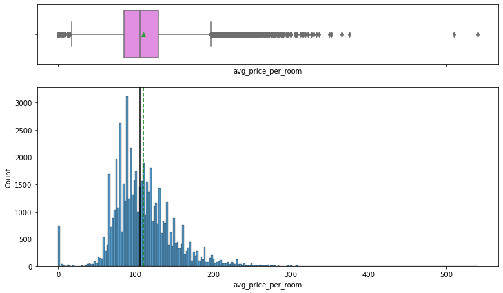

```python
histogram_boxplot(bc, 'avg_price_per_room')
```

#### Observations

1. The data is reasonably right skewed
2. the mean and median are very close to each other, both being slightly above €100

#### Observations on Number of Adults

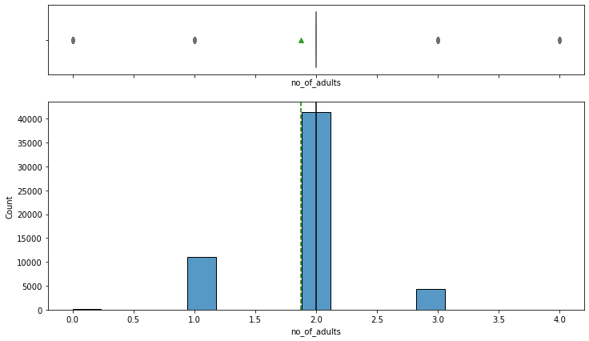

```python
histogram_boxplot(bc, 'no_of_adults')
```

#### Observations

1. Most times, 2 adults book a room together indicating that more couples book hotel rooms

## Bivariate Analysis

```python
# function to create labeled barplots


def labeled_barplot(data, feature, perc=False, n=None):
    """
    Barplot with percentage at the top

    data: dataframe
    feature: dataframe column
    perc: whether to display percentages instead of count (default is False)
    n: displays the top n category levels (default is None, i.e., display all levels)
    """

    total = len(data[feature])  # length of the column
    count = data[feature].nunique()
    if n is None:
        plt.figure(figsize=(count + 1, 5))
    else:
        plt.figure(figsize=(n + 1, 5))

    plt.xticks(rotation=90, fontsize=15)
    ax = sns.countplot(
        data=data,
        x=feature,
        palette="Paired",
        order=data[feature].value_counts().index[:n].sort_values(),
    )

    for p in ax.patches:
        if perc == True:
            label = "{:.1f}%".format(
                100 * p.get_height() / total
            )  # percentage of each class of the category
        else:
            label = p.get_height()  # count of each level of the category

        x = p.get_x() + p.get_width() / 2  # width of the plot
        y = p.get_height()  # height of the plot

        ax.annotate(
            label,
            (x, y),
            ha="center",
            va="center",
            size=12,
            xytext=(0, 5),
            textcoords="offset points",
        )  # annotate the percentage

    plt.show()  # show the plot
```

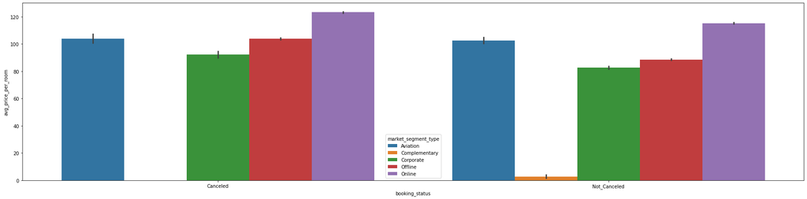

```python
plt.figure(figsize=(30,7))
sns.barplot(x='booking_status',y='avg_price_per_room',hue='market_segment_type',data=bc)
plt.show()
```

#### Observations on Months of the Year

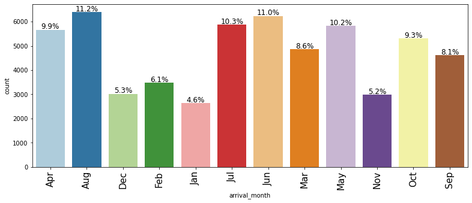

```python
labeled_barplot(bc, "arrival_month", perc=True)
```

#### Observations

1. The busiest month of the year is August with June coming a very close second
2. However, the trend shows that there is a general uptick in bookings from January with a peak in August then a downward trend from November which lasts till January with a pickup again in February
3. The 3 busiest months are between June to August which coincides with the Summer holidays

#### Observations on Market Segments

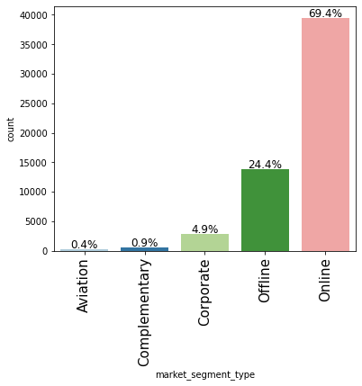

```python
labeled_barplot(bc, "market_segment_type", perc=True)
```

#### Observations on Market Segments wrt Room Prices

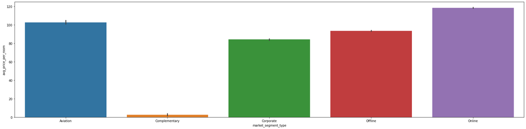

```python
plt.figure(figsize=(30,7))
sns.barplot(x='market_segment_type',y='avg_price_per_room',data=bc)
plt.show()
```

#### Observations

1. Online has the highest room prices. Despite this it has the highest number of guests as shown in the previous graph
2. Aviation has the second highest room price
3. Complementary has the lowest room price which makes sense as the segment name suggests it is free or almost free

#### Observations on Booking Status

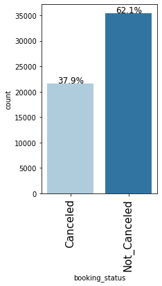

```python
labeled_barplot(bc, "booking_status", perc=True)
```

#### Observations

1. 62% of the guests do not cancel which is a high percentage and gives reasonable certainity to the hotel about their bookings

#### Observations on Booking Status wrt Repeat Guests

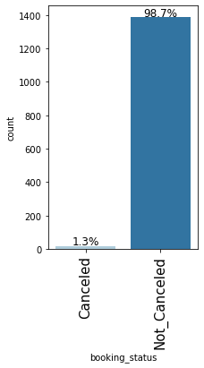

```python
#creation of a dataframe with only repated guests
rptd_sts=pd.DataFrame(bc[bc.repeated_guest == 1])

labeled_barplot(rptd_sts, "booking_status", perc=True)
```

```python
rptd_sts.shape
```

```
(1404, 18)
```

#### Observations

1. The number of guests under consideration is 1,404
2. For repeating guests, only 1.3% or about 18 guests cancel, which means the repeating guests genrally like the hotel

#### Observations on Special Requirements wrt Cancellation

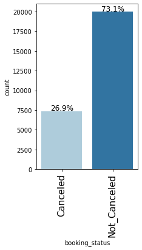

```python
#creation of a dataframe with only guests with special requirements
spcrqr_sts=pd.DataFrame(bc[bc.no_of_special_requests > 0])

labeled_barplot(spcrqr_sts, "booking_status", perc=True)
```

```python
spcrqr_sts.shape
```

```
(27352, 18)
```

#### Observations

1. The number of guests under consideration is 27,352
2. For guests with special requests, about 27% or ~7,300 guests cancel, which means the special requirements are not a major factor that affect cancellation for most of the guests that come to the hotel

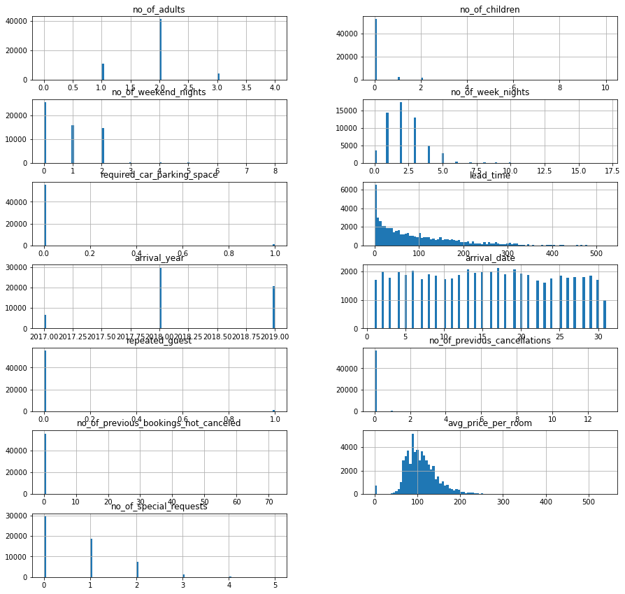

```python
columns = list(bc)[0:-1] # Excluding Outcome column which has only
bc[columns].hist(stacked=False, bins=100, figsize=(15,30), layout=(14,2));
```

### Data Correlation

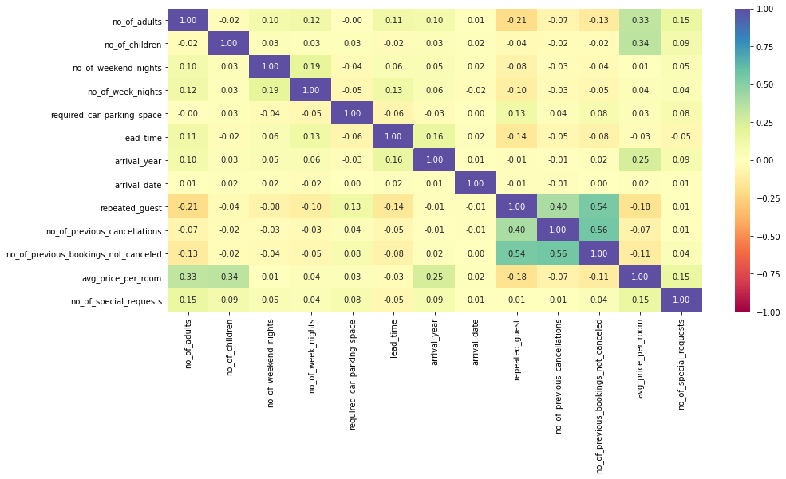

```python
numeric_columns = bc.select_dtypes(include=np.number).columns.tolist()

# correlation heatmap
plt.figure(figsize=(15, 7))
sns.heatmap(
    bc[numeric_columns].corr(),
    annot=True,
    vmin=-1,
    vmax=1,
    fmt=".2f",
    cmap="Spectral"
)
plt.show()
```

There are no really strong correlations between any of the variables

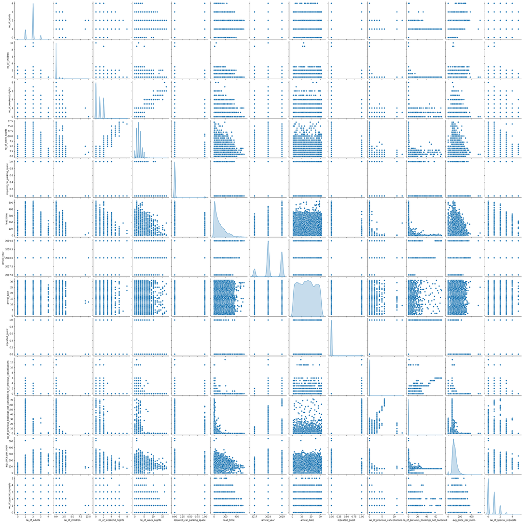

```python
sns.pairplot(bc,diag_kind='kde')
```

# Logistic Regression Model Building

1. We want to predict the booking status of a guest.
2. Before we proceed to build a model, we'll have to encode categorical features.
3. We'll split the data into train and test to be able to evaluate the model that we build on the train data.
4. We will build a Logistic Regression model using the train data and then check it's performance.

```python
##replacing booking_status with 0 and 1
##getting dummies

replaceStruct = {"booking_status":     {"Not_Canceled": 1, "Canceled": 0} }
oneHotCols=['type_of_meal_plan','room_type_reserved','market_segment_type','arrival_month'
           ]
```

```python
bc=bc.replace(replaceStruct)
bc2=pd.get_dummies(bc, columns=oneHotCols)
bc2.head(10)
```

|  | no_of_adults | no_of_children | no_of_weekend_nights | no_of_week_nights | required_car_parking_space | lead_time | arrival_year | arrival_date | repeated_guest | no_of_previous_cancellations | no_of_previous_bookings_not_canceled | avg_price_per_room | no_of_special_requests | booking_status | type_of_meal_plan_Meal Plan 1 | type_of_meal_plan_Meal Plan 2 | type_of_meal_plan_Meal Plan 3 | type_of_meal_plan_Not Selected | room_type_reserved_Room_Type 1 | room_type_reserved_Room_Type 2 | room_type_reserved_Room_Type 3 | room_type_reserved_Room_Type 4 | room_type_reserved_Room_Type 5 | room_type_reserved_Room_Type 6 | room_type_reserved_Room_Type 7 | market_segment_type_Aviation | market_segment_type_Complementary | market_segment_type_Corporate | market_segment_type_Offline | … |
| --- | --- | --- | --- | --- | --- | --- | --- | --- | --- | --- | --- | --- | --- | --- | --- | --- | --- | --- | --- | --- | --- | --- | --- | --- | --- | --- | --- | --- | --- | --- |
| 0 | 2 | 0 | 1 | 2 | 0 | 224 | 2017 | 2 | 0 | 0 | 0 | 65.00 | 0 | 1 | 1 | 0 | 0 | 0 | 1 | 0 | 0 | 0 | 0 | 0 | 0 | 0 | 0 | 0 | 1 | … |
| 1 | 2 | 0 | 2 | 3 | 0 | 5 | 2018 | 6 | 0 | 0 | 0 | 106.68 | 1 | 1 | 0 | 0 | 0 | 1 | 1 | 0 | 0 | 0 | 0 | 0 | 0 | 0 | 0 | 0 | 0 | … |
| 2 | 1 | 0 | 2 | 1 | 0 | 1 | 2018 | 28 | 0 | 0 | 0 | 60.00 | 0 | 0 | 1 | 0 | 0 | 0 | 1 | 0 | 0 | 0 | 0 | 0 | 0 | 0 | 0 | 0 | 0 | … |
| 3 | 2 | 0 | 0 | 2 | 0 | 211 | 2018 | 20 | 0 | 0 | 0 | 100.00 | 0 | 0 | 1 | 0 | 0 | 0 | 1 | 0 | 0 | 0 | 0 | 0 | 0 | 0 | 0 | 0 | 0 | … |
| 4 | 3 | 0 | 0 | 3 | 0 | 277 | 2019 | 13 | 0 | 0 | 0 | 89.10 | 2 | 0 | 0 | 0 | 0 | 1 | 1 | 0 | 0 | 0 | 0 | 0 | 0 | 0 | 0 | 0 | 0 | … |
| 5 | 2 | 0 | 1 | 1 | 0 | 48 | 2018 | 11 | 0 | 0 | 0 | 94.50 | 0 | 0 | 0 | 0 | 0 | 1 | 1 | 0 | 0 | 0 | 0 | 0 | 0 | 0 | 0 | 0 | 0 | … |
| 6 | 1 | 0 | 0 | 3 | 0 | 38 | 2019 | 20 | 0 | 0 | 0 | 160.00 | 1 | 1 | 1 | 0 | 0 | 0 | 1 | 0 | 0 | 0 | 0 | 0 | 0 | 0 | 0 | 0 | 0 | … |
| 7 | 2 | 0 | 0 | 2 | 0 | 346 | 2018 | 13 | 0 | 0 | 0 | 115.00 | 1 | 0 | 0 | 1 | 0 | 0 | 1 | 0 | 0 | 0 | 0 | 0 | 0 | 0 | 0 | 0 | 0 | … |
| 8 | 2 | 0 | 1 | 3 | 0 | 34 | 2017 | 15 | 0 | 0 | 0 | 107.55 | 1 | 1 | 1 | 0 | 0 | 0 | 1 | 0 | 0 | 0 | 0 | 0 | 0 | 0 | 0 | 0 | 0 | … |
| 9 | 2 | 0 | 0 | 4 | 0 | 133 | 2019 | 19 | 0 | 0 | 0 | 124.00 | 0 | 1 | 1 | 0 | 0 | 0 | 1 | 0 | 0 | 0 | 0 | 0 | 0 | 0 | 0 | 0 | 1 | … |

```python
notcncl = len(bc2.loc[bc2['booking_status'] == True])
cncl = len(bc2.loc[bc2['booking_status'] == False])
print("Number of not cancelled reservations: {0} ({1:2.2f}%)".format(notcncl, (notcncl / (notcncl + cncl)) * 100 ))
print("Number of cancelled reservations: {0} ({1:2.2f}%)".format(cncl, (cncl / (notcncl + cncl)) * 100))
```

```
Number of not cancelled reservations: 35378 (62.15%)
Number of cancelled reservations: 21548 (37.85%)
```

So we have 37.85% people in current data set who have cancelled their reservations and rest of 62.15% kept their reservations.

```python
X = bc2.drop('booking_status',axis=1)
Y = bc2['booking_status']

x_train, x_test, y_train, y_test = train_test_split(X, Y, test_size=0.3, random_state=1)
# 1 is just any random seed number

x_train.head()
```

|  | no_of_adults | no_of_children | no_of_weekend_nights | no_of_week_nights | required_car_parking_space | lead_time | arrival_year | arrival_date | repeated_guest | no_of_previous_cancellations | no_of_previous_bookings_not_canceled | avg_price_per_room | no_of_special_requests | type_of_meal_plan_Meal Plan 1 | type_of_meal_plan_Meal Plan 2 | type_of_meal_plan_Meal Plan 3 | type_of_meal_plan_Not Selected | room_type_reserved_Room_Type 1 | room_type_reserved_Room_Type 2 | room_type_reserved_Room_Type 3 | room_type_reserved_Room_Type 4 | room_type_reserved_Room_Type 5 | room_type_reserved_Room_Type 6 | room_type_reserved_Room_Type 7 | market_segment_type_Aviation | market_segment_type_Complementary | market_segment_type_Corporate | market_segment_type_Offline | market_segment_type_Online | … |
| --- | --- | --- | --- | --- | --- | --- | --- | --- | --- | --- | --- | --- | --- | --- | --- | --- | --- | --- | --- | --- | --- | --- | --- | --- | --- | --- | --- | --- | --- | --- |
| 15911 | 3 | 0 | 0 | 4 | 0 | 73 | 2018 | 6 | 0 | 0 | 0 | 149.40 | 0 | 1 | 0 | 0 | 0 | 0 | 0 | 0 | 1 | 0 | 0 | 0 | 0 | 0 | 0 | 0 | 1 | … |
| 27083 | 2 | 0 | 1 | 3 | 0 | 73 | 2018 | 19 | 0 | 0 | 0 | 149.40 | 1 | 1 | 0 | 0 | 0 | 0 | 0 | 0 | 1 | 0 | 0 | 0 | 0 | 0 | 0 | 0 | 1 | … |
| 25165 | 1 | 0 | 0 | 2 | 0 | 167 | 2018 | 5 | 0 | 0 | 0 | 78.20 | 0 | 1 | 0 | 0 | 0 | 1 | 0 | 0 | 0 | 0 | 0 | 0 | 0 | 0 | 0 | 1 | 0 | … |
| 30695 | 2 | 0 | 2 | 6 | 0 | 184 | 2017 | 17 | 0 | 0 | 0 | 65.29 | 1 | 1 | 0 | 0 | 0 | 0 | 1 | 0 | 0 | 0 | 0 | 0 | 0 | 0 | 0 | 0 | 1 | … |
| 6530 | 2 | 0 | 1 | 2 | 0 | 48 | 2018 | 21 | 0 | 0 | 0 | 85.50 | 1 | 1 | 0 | 0 | 0 | 1 | 0 | 0 | 0 | 0 | 0 | 0 | 0 | 0 | 0 | 1 | 0 | … |

### Checking the Data Split

```python
print("{0:0.2f}% data is in training set".format((len(x_train)/len(bc2.index)) * 100))
print("{0:0.2f}% data is in test set".format((len(x_test)/len(bc2.index)) * 100))
```

```
70.00% data is in training set
30.00% data is in test set
```

```python
print("Original Booking Status Not Cancelled Values    : {0} ({1:0.2f}%)".format(len(bc2.loc[bc2['booking_status'] == 1]), (len(bc2.loc[bc2['booking_status'] == 1])/len(bc2.index)) * 100))
print("Original Booking Status Cancelled Values   : {0} ({1:0.2f}%)".format(len(bc2.loc[bc2['booking_status'] == 0]), (len(bc2.loc[bc2['booking_status'] == 0])/len(bc2.index)) * 100))
print("")
print("Training Booking Status Not Cancelled Values    : {0} ({1:0.2f}%)".format(len(y_train[y_train[:] == 1]), (len(y_train[y_train[:] == 1])/len(y_train)) * 100))
print("Training Booking Status Cancelled Values   : {0} ({1:0.2f}%)".format(len(y_train[y_train[:] == 0]), (len(y_train[y_train[:] == 0])/len(y_train)) * 100))
print("")
print("Test Booking Status Not Cancelled Values        : {0} ({1:0.2f}%)".format(len(y_test[y_test[:] == 1]), (len(y_test[y_test[:] == 1])/len(y_test)) * 100))
print("Test Booking Status Cancelled Values       : {0} ({1:0.2f}%)".format(len(y_test[y_test[:] == 0]), (len(y_test[y_test[:] == 0])/len(y_test)) * 100))
print("")
```

```
Original Booking Status Not Cancelled Values    : 35378 (62.15%)
Original Booking Status Cancelled Values   : 21548 (37.85%)

Training Booking Status Not Cancelled Values    : 24733 (62.07%)
Training Booking Status Cancelled Values   : 15115 (37.93%)

Test Booking Status Not Cancelled Values        : 10645 (62.33%)
Test Booking Status Cancelled Values       : 6433 (37.67%)
```

```python
# Fit the model on train
model = LogisticRegression(solver="liblinear", random_state=1)
model.fit(x_train, y_train)
#predict on test
y_predict = model.predict(x_test)


coef_df = pd.DataFrame(model.coef_)
coef_df['intercept'] = model.intercept_
print(coef_df)
```

```
          0         1         2         3         4         5         6  \
0  0.061952  0.093484 -0.069493 -0.062873  0.664459 -0.017178  0.002205

          7         8         9        10        11        12        13  \
0 -0.001622  0.187046 -0.063628  0.308764 -0.020756  1.377746 -0.001555

         14        15       16       17        18        19        20  \
0  0.270324 -0.002689 -0.26521 -0.40818  0.044225  0.000394 -0.008713

         21        22        23        24        25        26        27  \
0  0.087832  0.162544  0.122768 -0.045653  0.031128 -0.215961  1.012373

         28        29        30        31        32        33        34  \
0 -0.781017 -0.301637  0.161038  0.992672 -0.679245  0.290339  0.101451

         35        36        37        38        39        40  intercept
0 -0.068285 -0.501937  0.172062 -0.377484 -0.022326  0.234221   0.000869
```

```python
model_score = model.score(x_test, y_test)
print(model_score)
```

```
0.7948823047195221
```

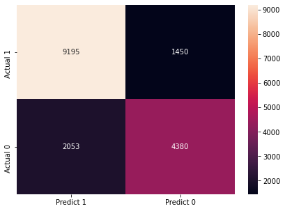

```python
cm=metrics.confusion_matrix(y_test, y_predict, labels=[1, 0])

df_cm = pd.DataFrame(cm, index = [i for i in ["Actual 1"," Actual 0"]],
                  columns = [i for i in ["Predict 1","Predict 0"]])
plt.figure(figsize = (7,5))
sns.heatmap(df_cm, annot=True,fmt='g')
plt.show()
```

The confusion matrix

True Positives (TP): we correctly predicted that they did not cancel 9,195

True Negatives (TN): we correctly predicted that they canceled 4,380

False Positives (FP): we incorrectly predicted that did not cancel (a "Type I error") 2,053 Falsely predict positive Type I error

False Negatives (FN): we incorrectly predicted that they cancelled (a "Type II error") 1,450 Falsely predict negative Type II error

## Decision Tree

```python
dTree = DecisionTreeClassifier(criterion = 'gini', random_state=1)
dTree.fit(x_train, y_train)
```

```
DecisionTreeClassifier(random_state=1)
```

#### Scoring the Decision Tree

```python
print("Accuracy on training set : ",dTree.score(x_train, y_train))
print("Accuracy on test set : ",dTree.score(x_test, y_test))
```

```
Accuracy on training set :  0.9944539249146758
Accuracy on test set :  0.848635671624312
```

```python
#Checking number of positives
Y.sum(axis = 0)
```

```
35378
```

#### Observations

```python
## Function to create confusion matrix
def make_confusion_matrix(model,y_actual,labels=[1, 0]):
    '''
    model : classifier to predict values of X
    y_actual : ground truth

    '''
    y_predict = model.predict(x_test)
    cm=metrics.confusion_matrix( y_actual, y_predict, labels=[0, 1])
    df_cm = pd.DataFrame(cm, index = [i for i in ["Actual - No","Actual - Yes"]],
                  columns = [i for i in ['Predicted - No','Predicted - Yes']])
    group_counts = ["{0:0.0f}".format(value) for value in
                cm.flatten()]
    group_percentages = ["{0:.2%}".format(value) for value in
                         cm.flatten()/np.sum(cm)]
    labels = [f"{v1}\n{v2}" for v1, v2 in
              zip(group_counts,group_percentages)]
    labels = np.asarray(labels).reshape(2,2)
    plt.figure(figsize = (10,7))
    sns.heatmap(df_cm, annot=labels,fmt='')
    plt.ylabel('True label')
    plt.xlabel('Predicted label')
```

```python
##  Function to calculate recall score
def get_recall_score(model):
    '''
    model : classifier to predict values of X

    '''
    pred_train = model.predict(x_train)
    pred_test = model.predict(x_test)
    print("Recall on training set : ",metrics.recall_score(y_train,pred_train))
    print("Recall on test set : ",metrics.recall_score(y_test,pred_test))
```

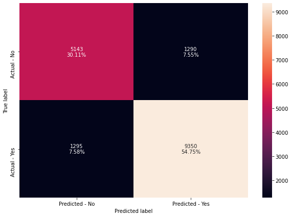

```python
make_confusion_matrix(dTree,y_test)
```

```python
# Recall on train and test
get_recall_score(dTree)
```

```
Recall on training set :  0.9948651599078154
Recall on test set :  0.878346641615782
```

### Visualizing the Decision Tree

```python
feature_names = list(X.columns)
print(feature_names)
```

[output not shown]

[figure not shown]

```python
plt.figure(figsize=(20,30))
tree.plot_tree(dTree,feature_names=feature_names,filled=True,fontsize=9,node_ids=True,class_names=True)
plt.show()
```

```python
# Text report showing the rules of a decision tree -

print(tree.export_text(dTree,feature_names=feature_names,show_weights=True))
```

```
|--- lead_time <= 151.50
|   |--- no_of_special_requests <= 0.50
|   |   |--- market_segment_type_Online <= 0.50
|   |   |   |--- lead_time <= 88.50
|   |   |   |   |--- avg_price_per_room <= 202.50
|   |   |   |   |   |--- no_of_weekend_nights <= 0.50
|   |   |   |   |   |   |--- market_segment_type_Corporate <= 0.50
|   |   |   |   |   |   |   |--- market_segment_type_Aviation <= 0.50
|   |   |   |   |   |   |   |   |--- weights: [0.00, 2102.00] class: 1
|   |   |   |   |   |   |   |--- market_segment_type_Aviation >  0.50
|   |   |   |   |   |   |   |   |--- lead_time <= 9.50
|   |   |   |   |   |   |   |   |   |--- avg_price_per_room <= 98.00
|   |   |   |   |   |   |   |   |   |   |--- arrival_date <= 22.50
|   |   |   |   |   |   |   |   |   |   |   |--- truncated branch of depth 4
|   |   |   |   |   |   |   |   |   |   |--- arrival_date >  22.50
|   |   |   |   |   |   |   |   |   |   |   |--- truncated branch of depth 5
|   |   |   |   |   |   |   |   |   |--- avg_price_per_room >  98.00
|   |   |   |   |   |   |   |   |   |   |--- weights: [0.00, 20.00] class: 1
|   |   |   |   |   |   |   |   |--- lead_time >  9.50
|   |   |   |   |   |   |   |   |   |--- no_of_week_nights <= 2.00
|   |   |   |   |   |   |   |   |   |   |--- no_of_previous_bookings_not_canceled <= 0.50
|   |   |   |   |   |   |   |   |   |   |   |--- weights: [5.00, 0.00] class: 0
|   |   |   |   |   |   |   |   |   |   |--- no_of_previous_bookings_not_canceled >  0.50
|   |   |   |   |   |   |   |   |   |   |   |--- weights: [0.00, 1.00] class: 1
|   |   |   |   |   |   |   |   |   |--- no_of_week_nights >  2.00
|   |   |   |   |   |   |   |   |   |   |--- weights: [0.00, 3.00] class: 1
|   |   |   |   |   |   |--- market_segment_type_Corporate >  0.50
|   |   |   |   |   |   |   |--- lead_time <= 36.50
|   |   |   |   |   |   |   |   |--- no_of_adults <= 1.50
|   |   |   |   |   |   |   |   |   |--- lead_time <= 16.50
|   |   |   |   |   |   |   |   |   |   |--- avg_price_per_room <= 63.70
|   |   |   |   |   |   |   |   |   |   |   |--- truncated branch of depth 4
|   |   |   |   |   |   |   |   |   |   |--- avg_price_per_room >  63.70
|   |   |   |   |   |   |   |   |   |   |   |--- truncated branch of depth 13
|   |   |   |   |   |   |   |   |   |--- lead_time >  16.50
|   |   |   |   |   |   |   |   |   |   |--- arrival_month_May <= 0.50
|   |   |   |   |   |   |   |   |   |   |   |--- truncated branch of depth 9
|   |   |   |   |   |   |   |   |   |   |--- arrival_month_May >  0.50
|   |   |   |   |   |   |   |   |   |   |   |--- weights: [5.00, 0.00] class: 0
|   |   |   |   |   |   |   |   |--- no_of_adults >  1.50
```

[output cut: 1464 more lines]

```
|   |   |   |   |   |   |--- room_type_reserved_Room_Type 1 <= 0.50
|   |   |   |   |   |   |   |--- lead_time <= 172.50
|   |   |   |   |   |   |   |   |--- lead_time <= 159.00
|   |   |   |   |   |   |   |   |   |--- weights: [2.00, 0.00] class: 0
|   |   |   |   |   |   |   |   |--- lead_time >  159.00
|   |   |   |   |   |   |   |   |   |--- weights: [0.00, 1.00] class: 1
|   |   |   |   |   |   |   |--- lead_time >  172.50
|   |   |   |   |   |   |   |   |--- weights: [11.00, 0.00] class: 0
|   |   |   |   |   |   |--- room_type_reserved_Room_Type 1 >  0.50
|   |   |   |   |   |   |   |--- no_of_week_nights <= 2.50
|   |   |   |   |   |   |   |   |--- weights: [1.00, 0.00] class: 0
|   |   |   |   |   |   |   |--- no_of_week_nights >  2.50
|   |   |   |   |   |   |   |   |--- weights: [0.00, 4.00] class: 1
|   |   |--- no_of_special_requests >  2.50
|   |   |   |--- weights: [0.00, 154.00] class: 1
```

```python
# importance of features in the tree building ( The importance of a feature is computed as the
#(normalized) total reduction of the criterion brought by that feature. It is also known as the Gini importance )

print (pd.DataFrame(dTree.feature_importances_, columns = ["Imp"], index = x_train.columns).sort_values(by = 'Imp', ascending = False))
```

```
                                           Imp
lead_time                             0.379234
avg_price_per_room                    0.159094
arrival_date                          0.086128
no_of_special_requests                0.077584
market_segment_type_Online            0.074227
no_of_week_nights                     0.041803
no_of_weekend_nights                  0.032846
no_of_adults                          0.019919
arrival_year                          0.014885
arrival_month_Dec                     0.013515
arrival_month_Apr                     0.007453
type_of_meal_plan_Meal Plan 1         0.006896
arrival_month_Jul                     0.006312
arrival_month_Jun                     0.006180
arrival_month_Mar                     0.006131
arrival_month_May                     0.005768
room_type_reserved_Room_Type 4        0.005553
required_car_parking_space            0.005466
arrival_month_Aug                     0.005346
type_of_meal_plan_Not Selected        0.005330
arrival_month_Nov                     0.004742
no_of_children                        0.004513
arrival_month_Feb                     0.004303
arrival_month_Oct                     0.004082
arrival_month_Jan                     0.003847
room_type_reserved_Room_Type 1        0.003697
market_segment_type_Corporate         0.003693
arrival_month_Sep                     0.002651
type_of_meal_plan_Meal Plan 2         0.002488
room_type_reserved_Room_Type 5        0.001699
room_type_reserved_Room_Type 2        0.001449
market_segment_type_Offline           0.000650
room_type_reserved_Room_Type 7        0.000632
room_type_reserved_Room_Type 6        0.000598
no_of_previous_bookings_not_canceled  0.000389
market_segment_type_Aviation          0.000344
no_of_previous_cancellations          0.000326
repeated_guest                        0.000225
market_segment_type_Complementary     0.000000
room_type_reserved_Room_Type 3        0.000000
type_of_meal_plan_Meal Plan 3         0.000000
```

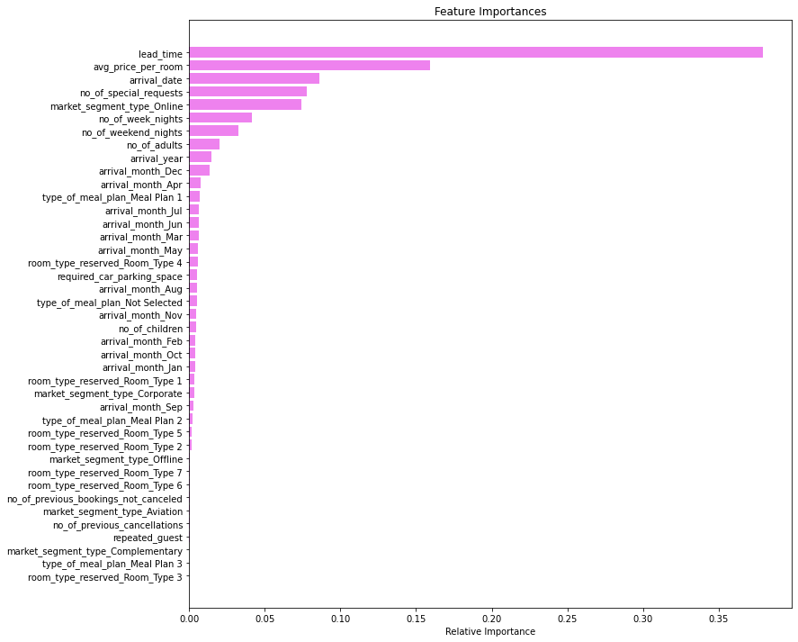

```python
importances = dTree.feature_importances_
indices = np.argsort(importances)

plt.figure(figsize=(12,12))
plt.title('Feature Importances')
plt.barh(range(len(indices)), importances[indices], color='violet', align='center')
plt.yticks(range(len(indices)), [feature_names[i] for i in indices])
plt.xlabel('Relative Importance')
plt.show()
```

#### Observations

1. According to the decision tree model, *lead_time* is the most important variable for predicting the booking_status.
2. The decision tree is very complex due to overfitting

### Reduction in Overfitting

#### Max Depth Approach - Max Depth 5

```python
dTree1 = DecisionTreeClassifier(criterion = 'gini',max_depth=5,random_state=1)
dTree1.fit(x_train, y_train)
```

```
DecisionTreeClassifier(max_depth=5, random_state=1)
```

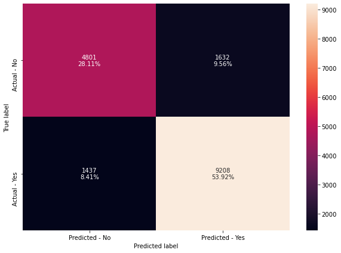

```python
make_confusion_matrix(dTree1, y_test)
```

```python
# Accuracy on train and test
print("Accuracy on training set : ",dTree1.score(x_train, y_train))
print("Accuracy on test set : ",dTree1.score(x_test, y_test))
# Recall on train and test
get_recall_score(dTree1)
```

```
Accuracy on training set :  0.8159255169644649
Accuracy on test set :  0.8202951165241832
Recall on training set :  0.8608337039582744
Recall on test set :  0.8650070455612964
```

#### Observations

Recall has reduced from 1 to 0.865 indicating that the overfitting has reduced and the model is now general

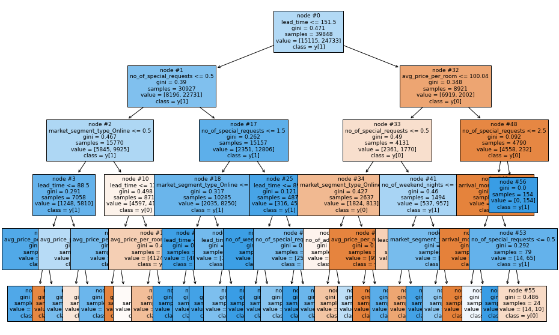

```python
plt.figure(figsize=(15,10))

tree.plot_tree(dTree1,feature_names=feature_names,filled=True,fontsize=9,node_ids=True,class_names=True)
plt.show()
```

```python
# Text report showing the rules of a decision tree -

print(tree.export_text(dTree1,feature_names=feature_names,show_weights=True))
```

```
|--- lead_time <= 151.50
|   |--- no_of_special_requests <= 0.50
|   |   |--- market_segment_type_Online <= 0.50
|   |   |   |--- lead_time <= 88.50
|   |   |   |   |--- avg_price_per_room <= 202.50
|   |   |   |   |   |--- weights: [556.00, 4753.00] class: 1
|   |   |   |   |--- avg_price_per_room >  202.50
|   |   |   |   |   |--- weights: [19.00, 1.00] class: 0
|   |   |   |--- lead_time >  88.50
|   |   |   |   |--- avg_price_per_room <= 93.33
|   |   |   |   |   |--- weights: [214.00, 687.00] class: 1
|   |   |   |   |--- avg_price_per_room >  93.33
|   |   |   |   |   |--- weights: [459.00, 369.00] class: 0
|   |   |--- market_segment_type_Online >  0.50
|   |   |   |--- lead_time <= 13.50
|   |   |   |   |--- avg_price_per_room <= 202.67
|   |   |   |   |   |--- weights: [396.00, 1560.00] class: 1
|   |   |   |   |--- avg_price_per_room >  202.67
|   |   |   |   |   |--- weights: [77.00, 2.00] class: 0
|   |   |   |--- lead_time >  13.50
|   |   |   |   |--- avg_price_per_room <= 99.88
|   |   |   |   |   |--- weights: [1162.00, 1118.00] class: 0
|   |   |   |   |--- avg_price_per_room >  99.88
|   |   |   |   |   |--- weights: [2962.00, 1435.00] class: 0
|   |--- no_of_special_requests >  0.50
|   |   |--- no_of_special_requests <= 1.50
|   |   |   |--- market_segment_type_Online <= 0.50
|   |   |   |   |--- lead_time <= 91.50
|   |   |   |   |   |--- weights: [10.00, 1191.00] class: 1
|   |   |   |   |--- lead_time >  91.50
|   |   |   |   |   |--- weights: [30.00, 253.00] class: 1
|   |   |   |--- market_segment_type_Online >  0.50
|   |   |   |   |--- lead_time <= 6.50
|   |   |   |   |   |--- weights: [60.00, 1151.00] class: 1
|   |   |   |   |--- lead_time >  6.50
|   |   |   |   |   |--- weights: [1935.00, 5655.00] class: 1
|   |   |--- no_of_special_requests >  1.50
|   |   |   |--- lead_time <= 89.50
|   |   |   |   |--- no_of_week_nights <= 3.50
|   |   |   |   |   |--- weights: [0.00, 3272.00] class: 1
```

[output cut: 30 more lines]

```
|   |   |   |   |   |--- weights: [232.00, 546.00] class: 1
|   |--- avg_price_per_room >  100.04
|   |   |--- no_of_special_requests <= 2.50
|   |   |   |--- arrival_month_Dec <= 0.50
|   |   |   |   |--- arrival_month_Jan <= 0.50
|   |   |   |   |   |--- weights: [4532.00, 0.00] class: 0
|   |   |   |   |--- arrival_month_Jan >  0.50
|   |   |   |   |   |--- weights: [12.00, 13.00] class: 1
|   |   |   |--- arrival_month_Dec >  0.50
|   |   |   |   |--- no_of_special_requests <= 0.50
|   |   |   |   |   |--- weights: [0.00, 55.00] class: 1
|   |   |   |   |--- no_of_special_requests >  0.50
|   |   |   |   |   |--- weights: [14.00, 10.00] class: 0
|   |   |--- no_of_special_requests >  2.50
|   |   |   |--- weights: [0.00, 154.00] class: 1
```

```python
# importance of features in the tree building ( The importance of a feature is computed as the
#(normalized) total reduction of the criterion brought by that feature. It is also known as the Gini importance )

print (pd.DataFrame(dTree1.feature_importances_, columns = ["Imp"], index = x_train.columns).sort_values(by = 'Imp', ascending = False))
```

```
                                           Imp
lead_time                             0.530711
no_of_special_requests                0.160782
market_segment_type_Online            0.156635
avg_price_per_room                    0.110278
no_of_adults                          0.015859
arrival_month_Dec                     0.012240
no_of_weekend_nights                  0.010544
arrival_month_Jan                     0.001576
no_of_week_nights                     0.001375
arrival_month_Oct                     0.000000
market_segment_type_Complementary     0.000000
market_segment_type_Corporate         0.000000
market_segment_type_Offline           0.000000
arrival_month_Apr                     0.000000
arrival_month_Aug                     0.000000
arrival_month_Feb                     0.000000
arrival_month_Nov                     0.000000
room_type_reserved_Room_Type 7        0.000000
arrival_month_Jul                     0.000000
arrival_month_Jun                     0.000000
arrival_month_Mar                     0.000000
arrival_month_May                     0.000000
market_segment_type_Aviation          0.000000
room_type_reserved_Room_Type 4        0.000000
room_type_reserved_Room_Type 6        0.000000
type_of_meal_plan_Meal Plan 1         0.000000
required_car_parking_space            0.000000
arrival_year                          0.000000
arrival_date                          0.000000
repeated_guest                        0.000000
no_of_previous_cancellations          0.000000
no_of_previous_bookings_not_canceled  0.000000
type_of_meal_plan_Meal Plan 2         0.000000
room_type_reserved_Room_Type 5        0.000000
type_of_meal_plan_Meal Plan 3         0.000000
type_of_meal_plan_Not Selected        0.000000
room_type_reserved_Room_Type 1        0.000000
room_type_reserved_Room_Type 2        0.000000
room_type_reserved_Room_Type 3        0.000000
no_of_children                        0.000000
arrival_month_Sep                     0.000000
```

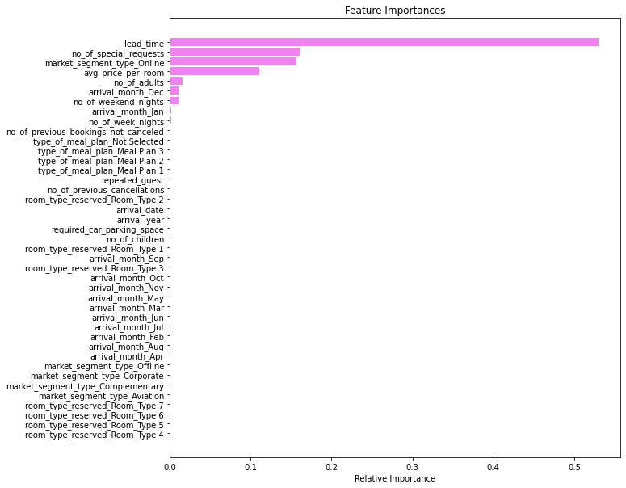

```python
importances = dTree1.feature_importances_
indices = np.argsort(importances)

plt.figure(figsize=(10,10))
plt.title('Feature Importances')
plt.barh(range(len(indices)), importances[indices], color='violet', align='center')
plt.yticks(range(len(indices)), [feature_names[i] for i in indices])
plt.xlabel('Relative Importance')
plt.show()
```